# TIGPS2023手足問卷成果報告

### 現實霸凌受害_反應_告訴老師 (樣本數=77)

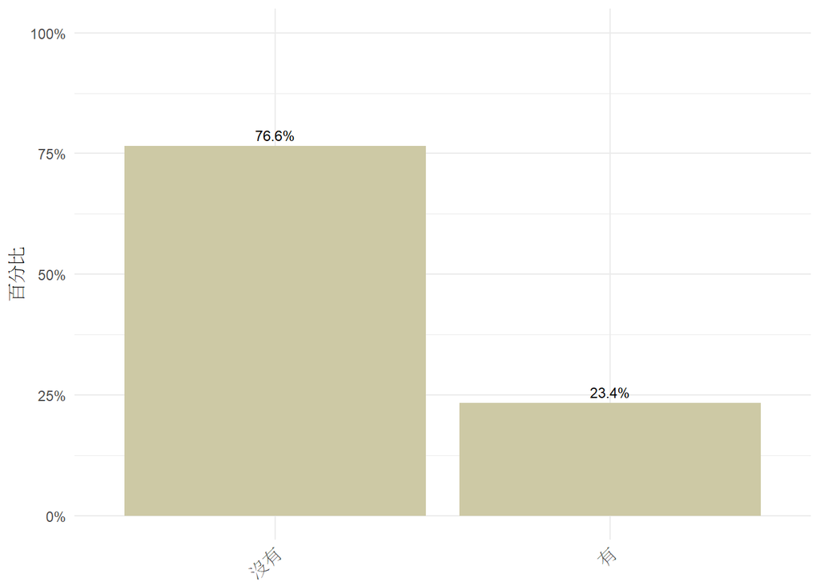

### 現實霸凌受害_反應_改變郵件帳號、電話號碼或網路封鎖讓當事人無法聯繫到我 (樣本數=77)

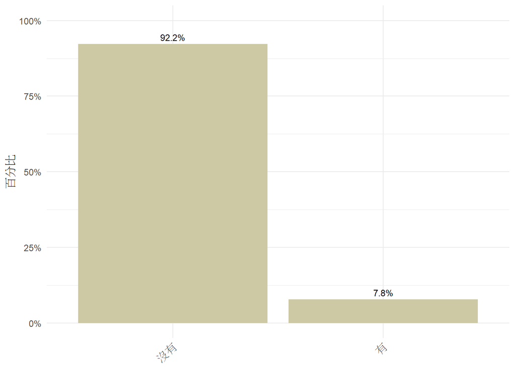

### 現實霸凌受害_反應_其他 (樣本數=77)

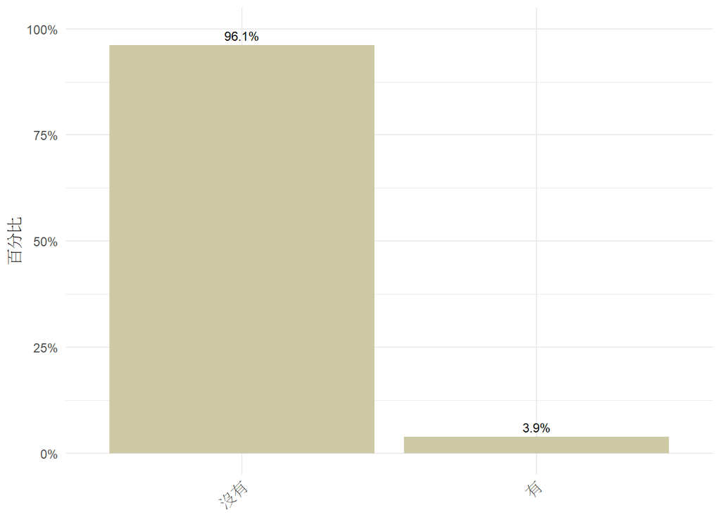

### 現實霸凌加害 (樣本數=596)

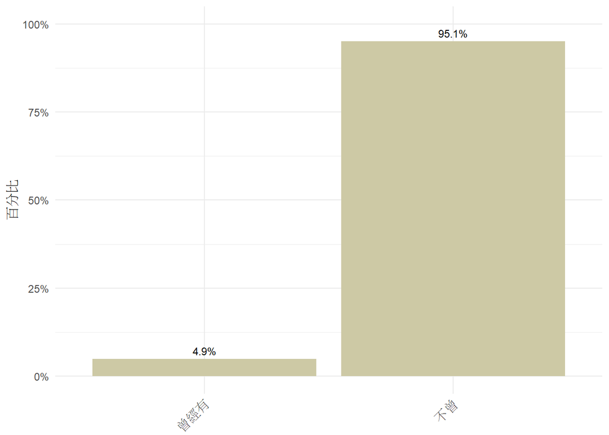

### 現實霸凌加害_用髒話罵或威脅某人 (樣本數=28)

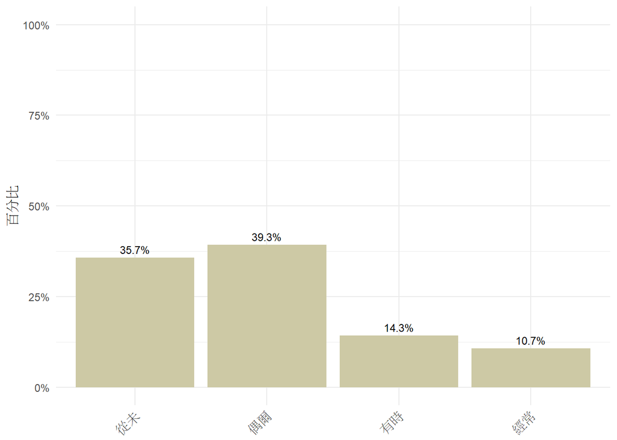

### 現實霸凌加害_說某人的壞話 (樣本數=28)

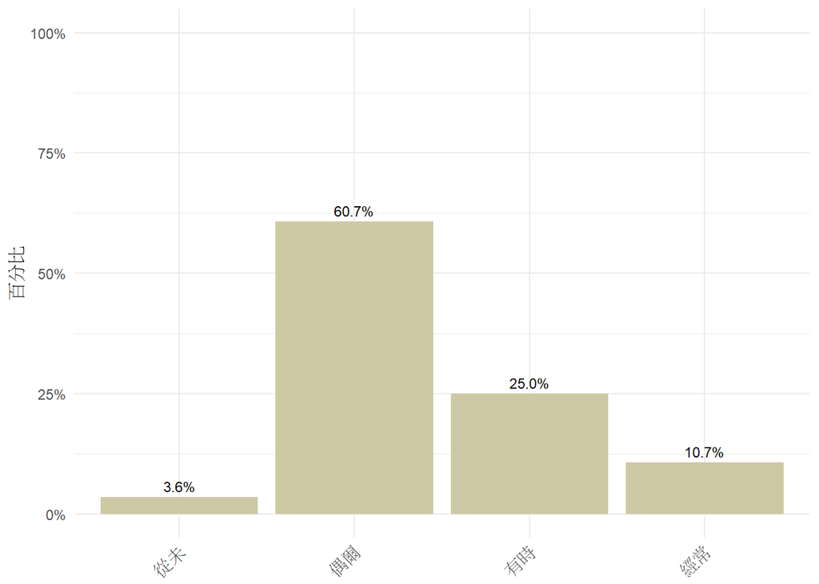

### 現實霸凌加害_不讓某人加入活動、討論事情或不准別人跟某人說話、一起行動 (樣本數=28)

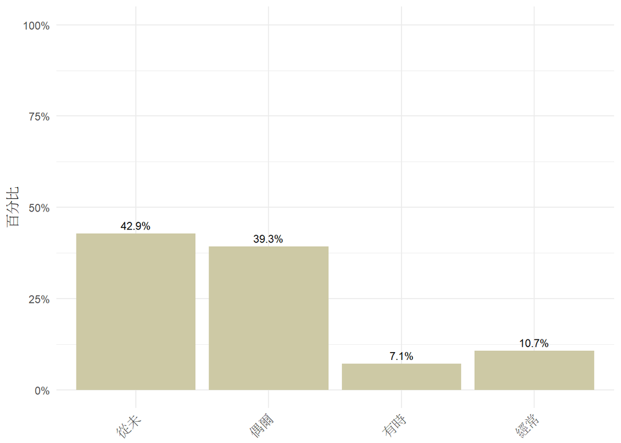

### 現實霸凌加害_嘲笑某人的外貌或言行舉止 (樣本數=28)

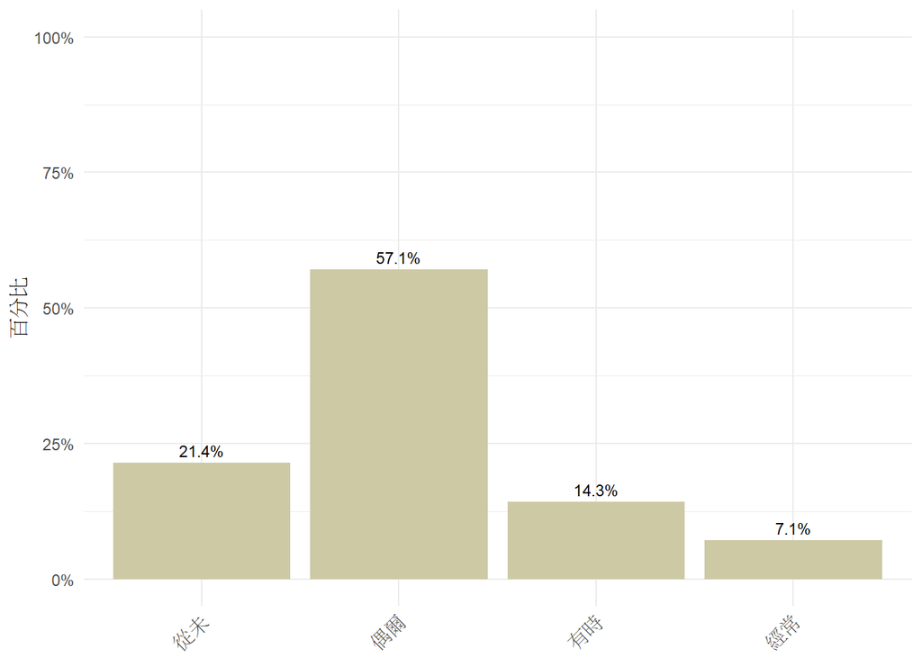

### 現實霸凌加害_嘲笑某人他喜歡某個人 (樣本數=28)

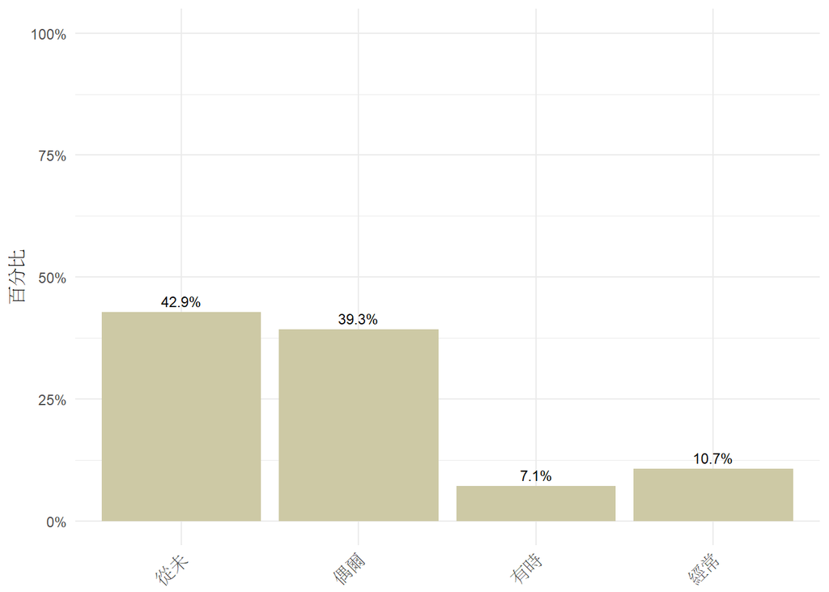

### 現實霸凌加害_故意破壞某人的東西或故意藏起來 (樣本數=28)

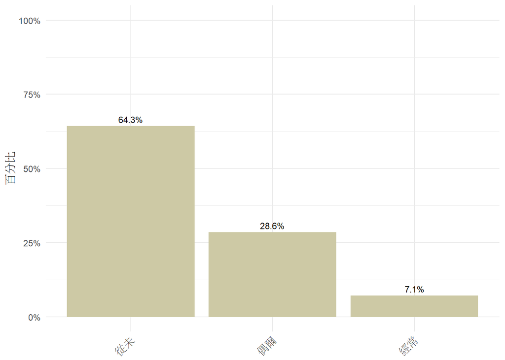

### 現實霸凌加害_勒索或強要某人的東西 (樣本數=28)

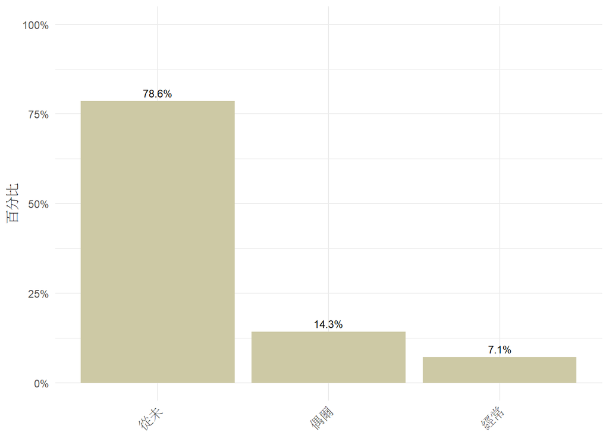

### 現實霸凌加害_對某人肢體攻擊 (樣本數=28)

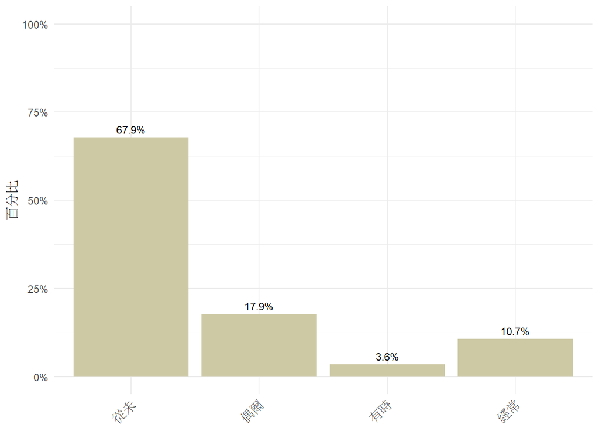

### 現實霸凌加害_對象_同班同學 (樣本數=24)

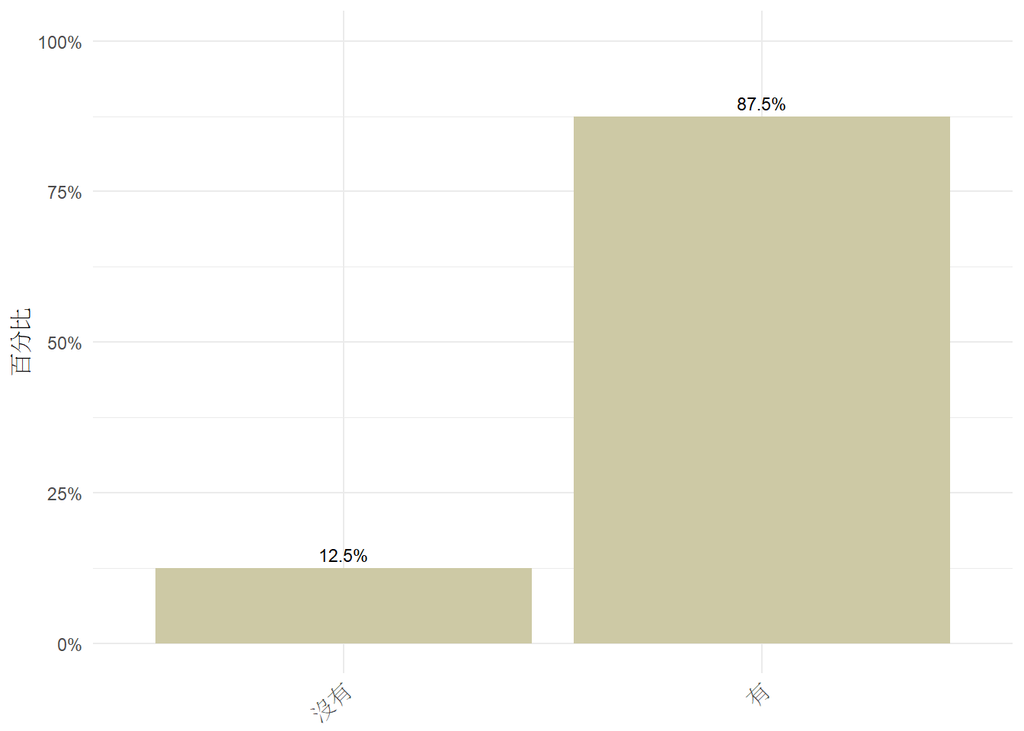

### 現實霸凌加害_對象_同校不同班的同學 (樣本數=24)

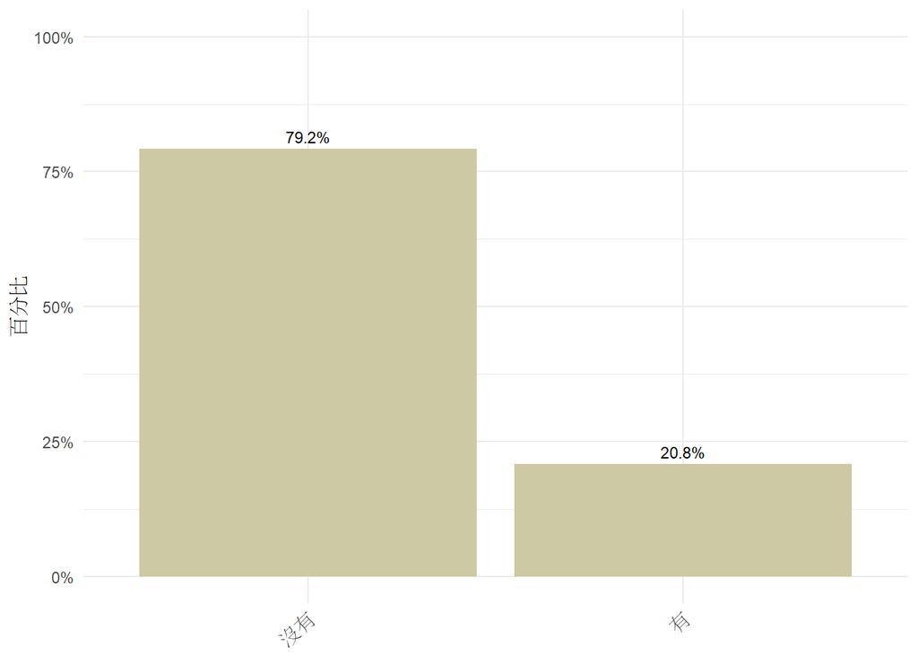

### 現實霸凌加害_對象_不同校的朋友 (樣本數=24)

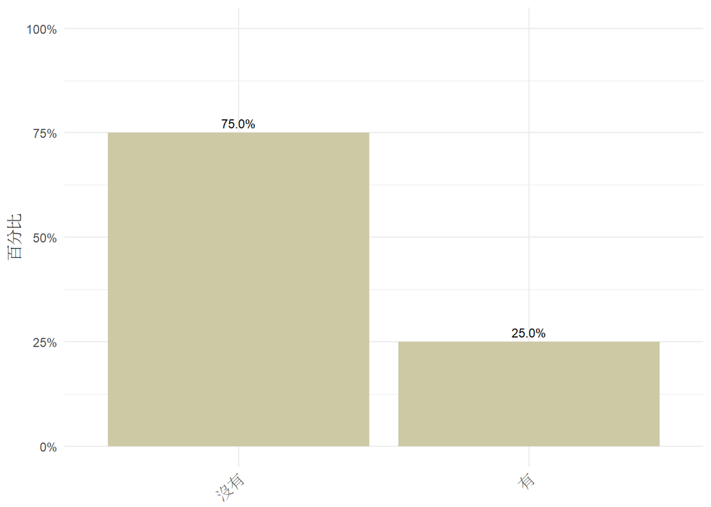

### 現實霸凌加害_對象_鄰居 (樣本數=24)

### 現實霸凌加害_對象_其他 (樣本數=24)

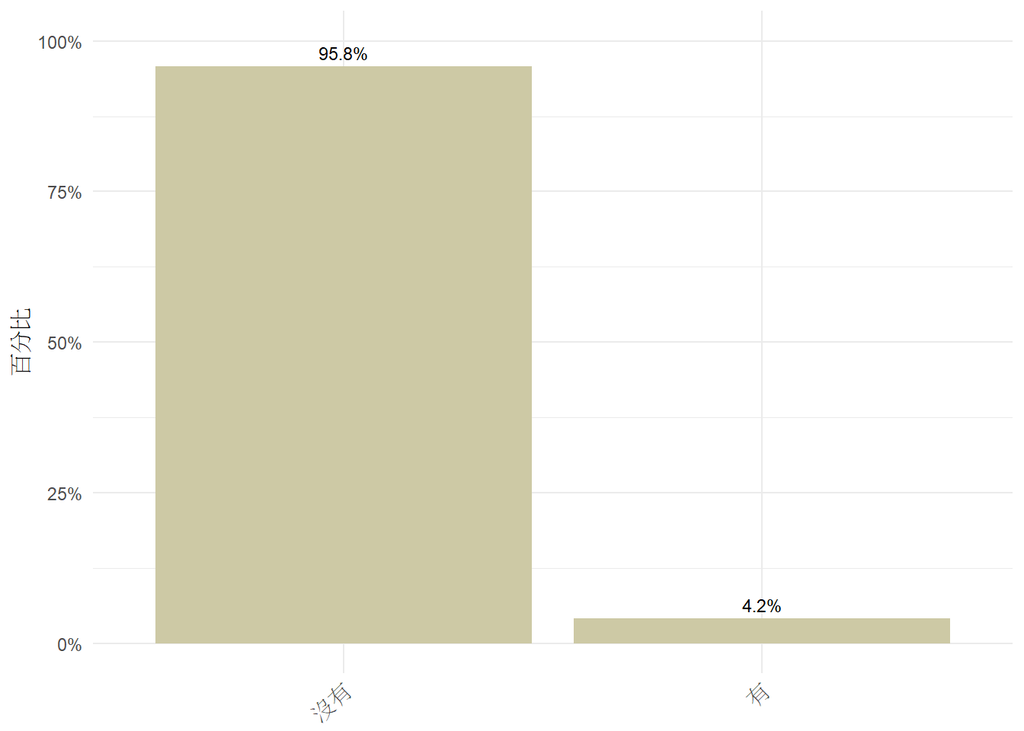

### 網路霸凌受害 (樣本數=595)

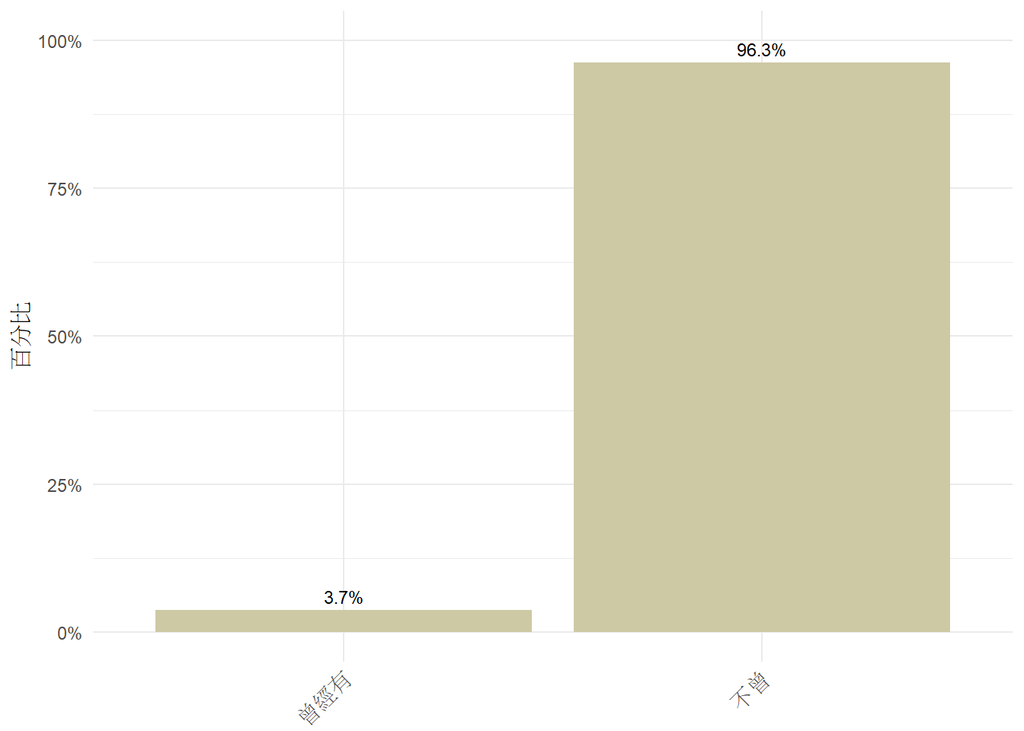

### 網路霸凌受害_別人用髒話罵或威脅我 (樣本數=21)

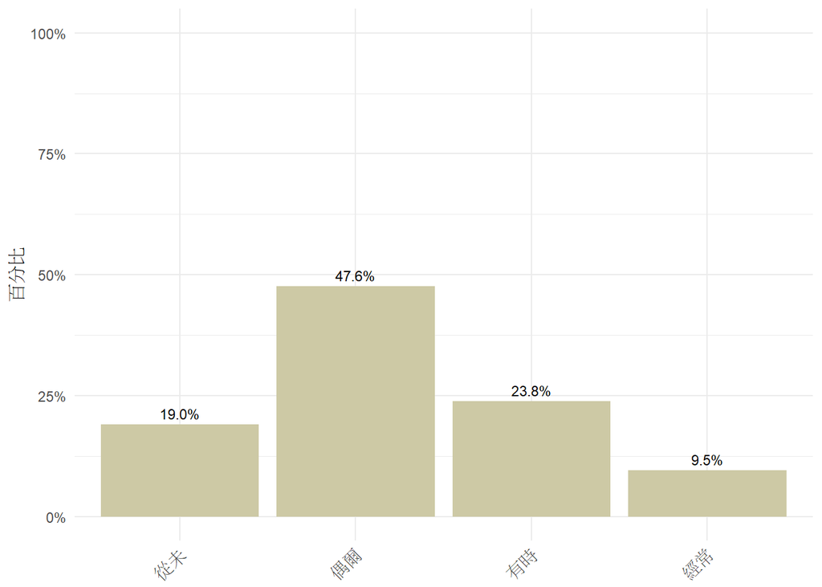

### 網路霸凌受害_別人說我的壞話 (樣本數=21)

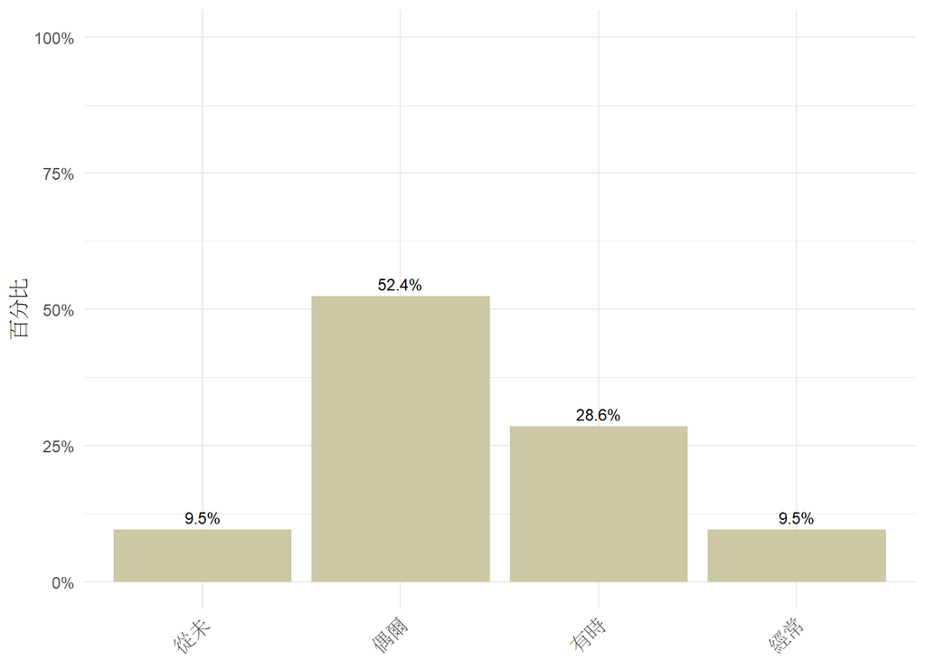

### 網路霸凌受害_不讓我加入討論 (樣本數=21)

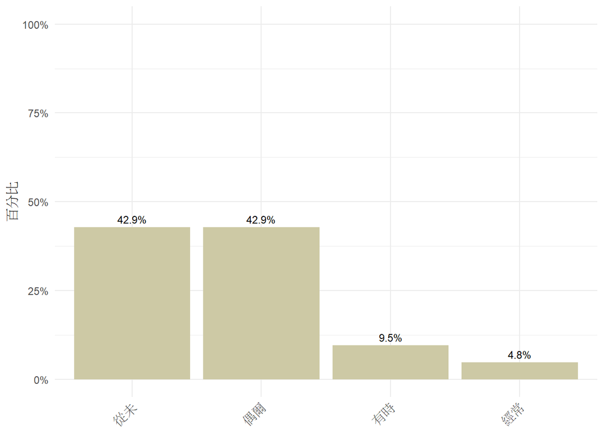

### 網路霸凌受害_被嘲笑外貌、言行舉止 (樣本數=21)

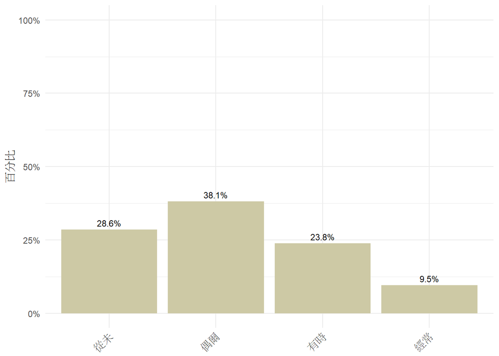

### 網路霸凌受害_被嘲笑我喜歡某人 (樣本數=21)

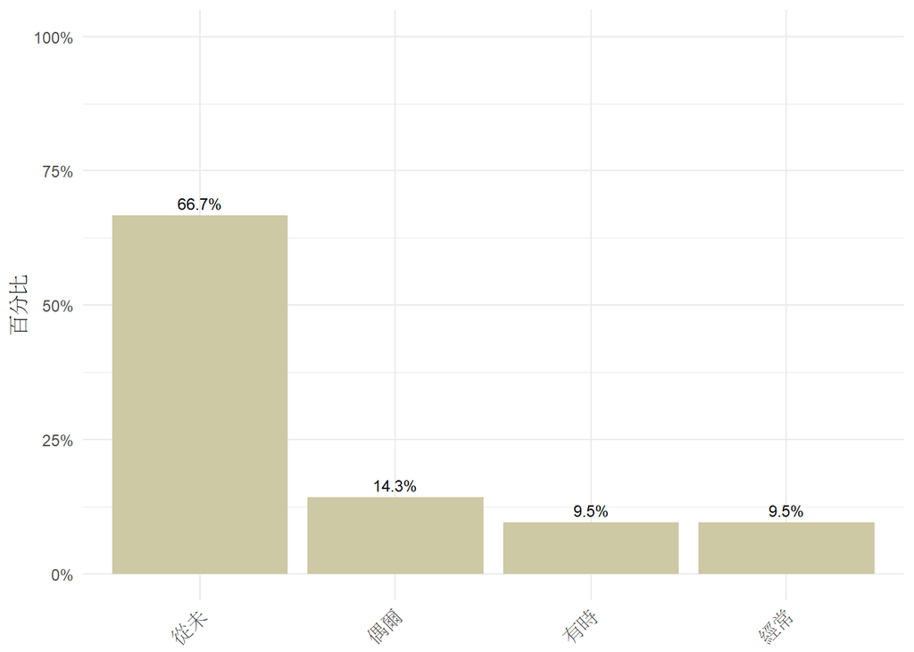

### 網路霸凌受害_在網路散布使我丟臉的照片或影片 (樣本數=21)

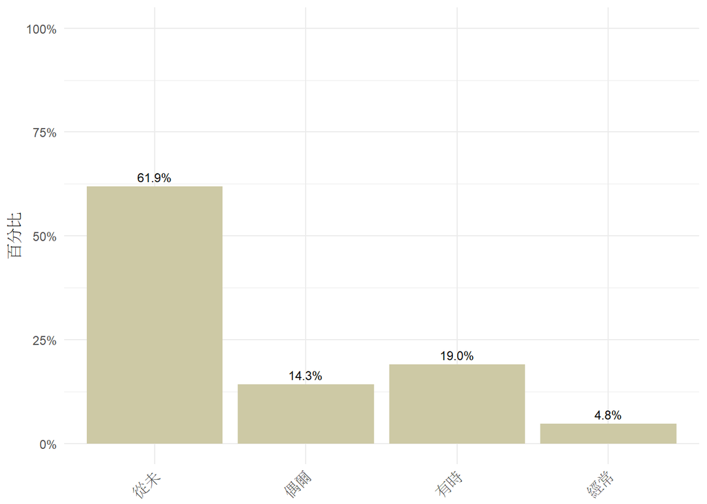

### 網路霸凌受害_假冒我的社交帳號或是電子郵件，在網路上發布不實訊息 (樣本數=21)

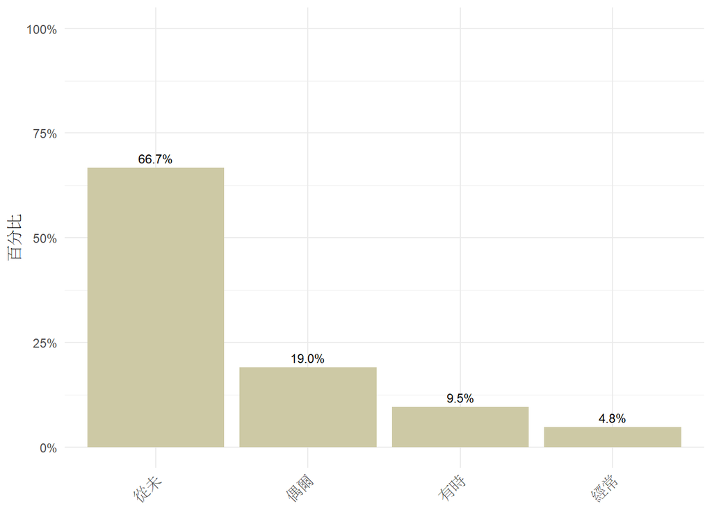

### 網路霸凌受害_對象_同班同學 (樣本數=20)

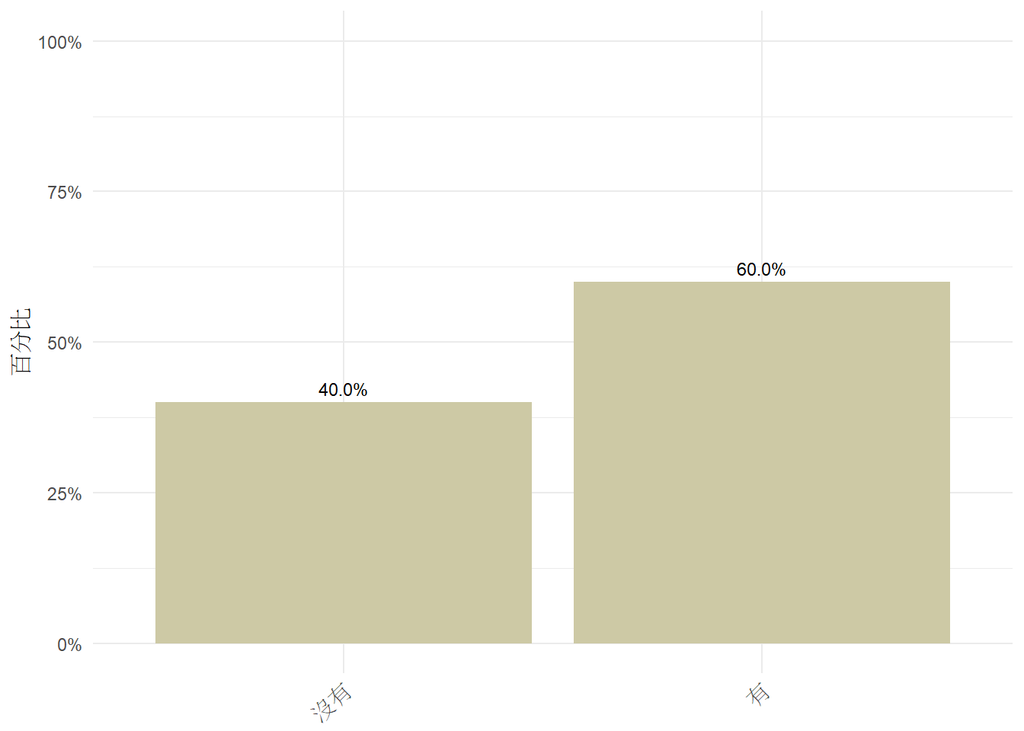

### 網路霸凌受害_對象_同校不同班的同學 (樣本數=20)

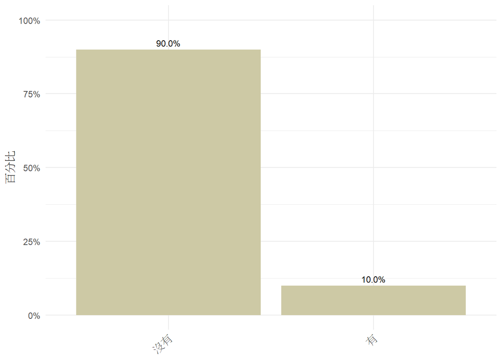

### 網路霸凌受害_對象_不同校的朋友 (樣本數=20)

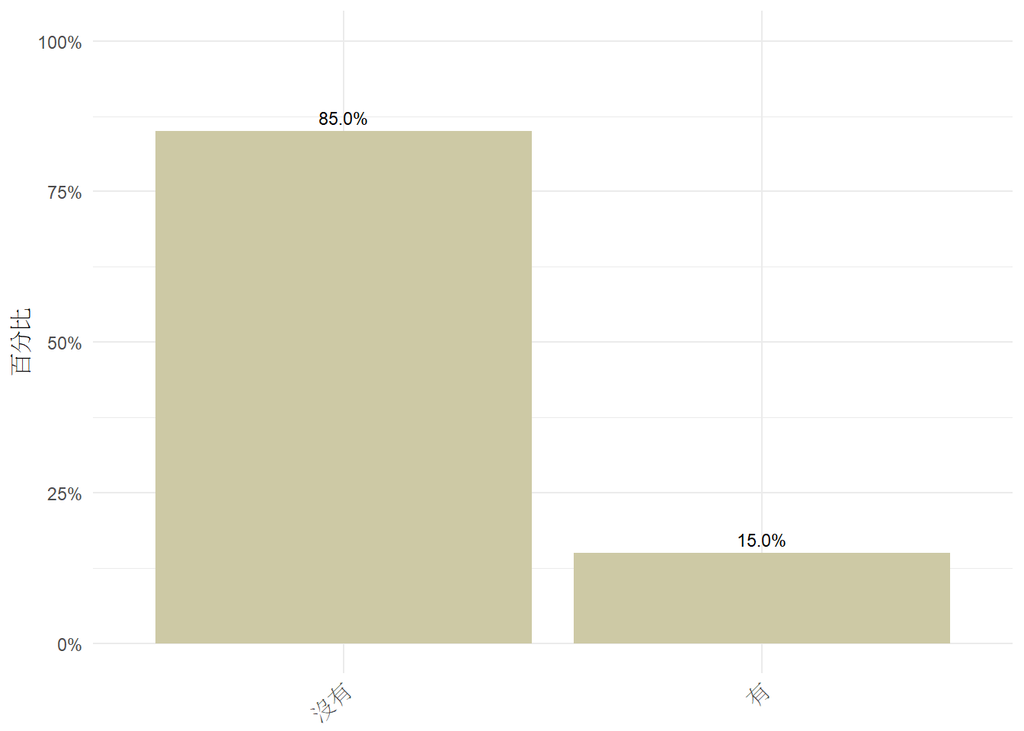

### 網路霸凌受害_對象_鄰居 (樣本數=20)

### 網路霸凌受害_對象_其他 (樣本數=20)

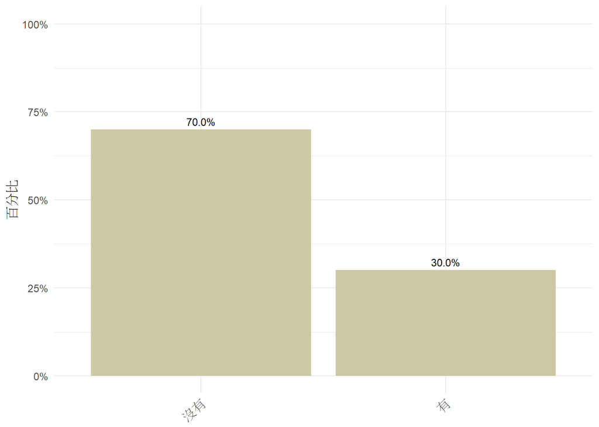

### 網路霸凌受害_反應_好好說明澄清 (樣本數=21)

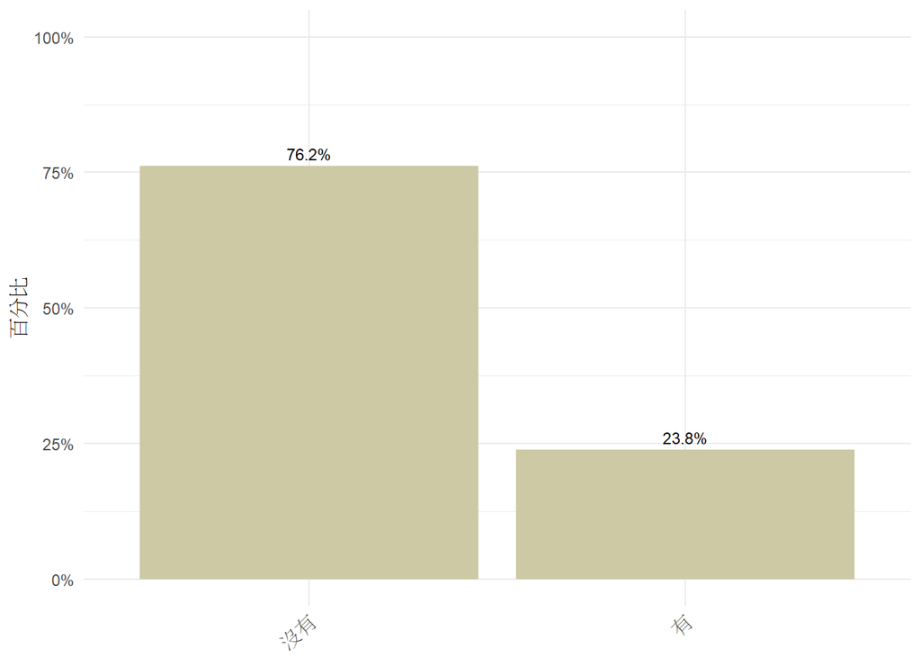

### 網路霸凌受害_反應_要求當事人停止 (樣本數=21)

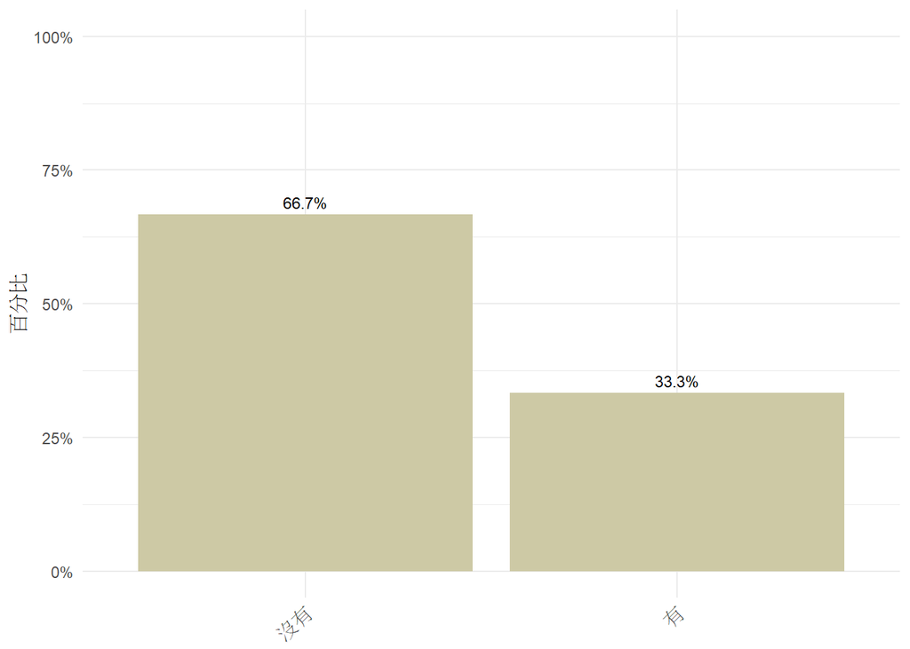

### 網路霸凌受害_反應_忽略這些人與事情 (樣本數=21)

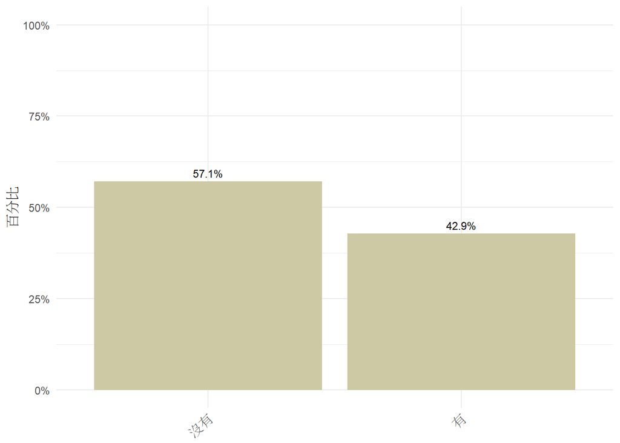

### 網路霸凌受害_反應_投入其他有趣或有意義的事情 (樣本數=21)

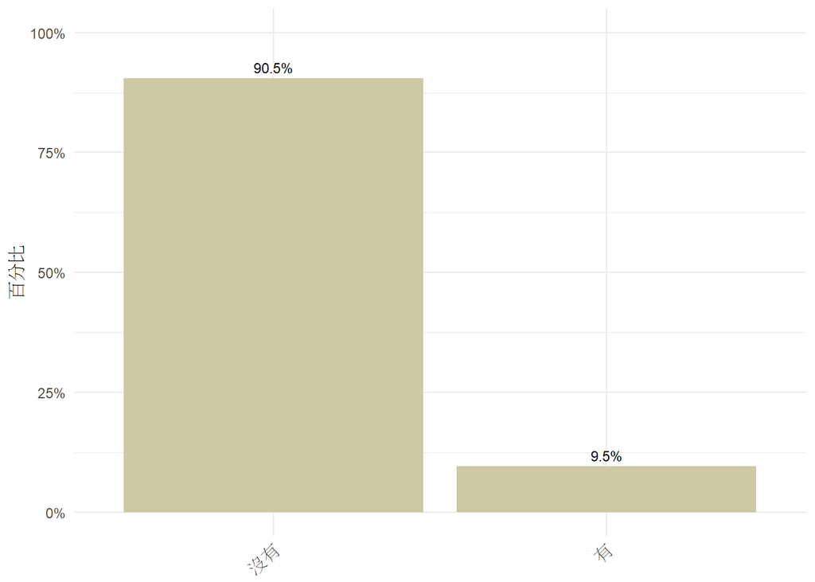